# PCA pipeline

PCA analyses for “Target capture reveals complex origin of Vietnamese ginseng”

Vincent Manzanilla https://github.com/vincentmanz/ (Postdoc at BaseClear/ Analyst at Data.Labs)  
2021-06-10

# 1 Convert VCF to GDS

```r
seqVCF2GDS("../PCA/deepvariant.cohort_filtered.vcf.gz", "deepvariant.cohort_filtered.gcf")
```

```
Thu Jun 10 10:17:53 2021
Variant Call Format (VCF) Import:
    file(s):
        deepvariant.cohort_filtered.vcf.gz (282.9K)
    file format: VCFv4.2
    genome reference: <unknown>
    the number of sets of chromosomes (ploidy): 2
    the number of samples: 282
    genotype storage: bit2
    compression method: LZMA_RA
    # of samples: 282
Output:
    deepvariant.cohort_filtered.gcf
Parsing 'deepvariant.cohort_filtered.vcf.gz':
+ genotype/data   { Bit2 2x282x145 LZMA_ra, 42B }
Digests:
    sample.id  [md5: 6274f1a64dac6c8267e3d8f75885a149]
    variant.id  [md5: d00be331f952fd95b3f366563bfc7f87]
    position  [md5: 7f19dd8f4cf695840d13376911c88ff1]
    chromosome  [md5: b8027f9a201e96a42026fac44a468b63]
    allele  [md5: 12977f98a21361f4650bf1b737768ea5]
    genotype  [md5: 7ac576403c18405af5af02c4299d3b93]
    phase  [md5: 29f7da1ff61be8ed5db94b3f246d739b]
    annotation/id  [md5: d7133c26fb600ac5649ddf215e33ddad]
    annotation/qual  [md5: fd7721239eab0345659bc57f4fbba8de]
    annotation/filter  [md5: 6ee42c6cf83bc6ed83729212b1943699]
    annotation/info/AF  [md5: 6e6dcb39f4b68c5a7dc6ad670c6ff366]
    annotation/info/AQ  [md5: 6e6dcb39f4b68c5a7dc6ad670c6ff366]
    annotation/info/AC  [md5: 6e6dcb39f4b68c5a7dc6ad670c6ff366]
    annotation/info/AN  [md5: 6ee42c6cf83bc6ed83729212b1943699]
    annotation/format/RNC  [md5: 6a6fa33cbd419faffc7231cd98c63b1c]
    annotation/format/DP  [md5: ccc90584bbd7feebbc74e6dae5d73eb8]
    annotation/format/AD  [md5: b18b284987fd74feabf45087b9f28b18]
    annotation/format/GQ  [md5: e87ae6a240d11fd22ec3bc10fc6f0265]
    annotation/format/PL  [md5: f4147be486e20224ec4d1baf155f66b1]
Done.
Thu Jun 10 10:17:53 2021
Optimize the access efficiency ...
Clean up the fragments of GDS file:
    open the file 'deepvariant.cohort_filtered.gcf' (211.5K)
    # of fragments: 201
    save to 'deepvariant.cohort_filtered.gcf.tmp'
    rename 'deepvariant.cohort_filtered.gcf.tmp' (210.2K, reduced: 1.2K)
    # of fragments: 95
Thu Jun 10 10:17:53 2021
```

```r
showfile.gds(closeall = TRUE)
gds <- seqOpen("deepvariant.cohort_filtered.gcf")
gds
```

```
Object of class "SeqVarGDSClass"
File: /home/vincent/Project/Ginseng/PCA/deepvariant.cohort_filtered.gcf (210.2K)
+    [  ] *
|--+ description   [  ] *
|--+ sample.id   { Str8 282 LZMA_ra(36.7%), 389B } *
|--+ variant.id   { Int32 145 LZMA_ra(39.7%), 237B } *
|--+ position   { Int32 145 LZMA_ra(63.1%), 373B } *
|--+ chromosome   { Str8 145 LZMA_ra(12.4%), 241B } *
|--+ allele   { Str8 145 LZMA_ra(41.0%), 245B } *
|--+ genotype   [  ] *
|  |--+ data   { Bit2 2x282x145 LZMA_ra(18.5%), 3.7K } *
|  |--+ extra.index   { Int32 3x0 LZMA_ra, 18B } *
|  \--+ extra   { Int16 0 LZMA_ra, 18B }
|--+ phase   [  ]
|  |--+ data   { Bit1 282x145 LZMA_ra(2.15%), 117B } *
|  |--+ extra.index   { Int32 3x0 LZMA_ra, 18B } *
|  \--+ extra   { Bit1 0 LZMA_ra, 18B }
|--+ annotation   [  ]
|  |--+ id   { Str8 145 LZMA_ra(25.9%), 817B } *
|  |--+ qual   { Float32 145 LZMA_ra(45.2%), 269B } *
|  |--+ filter   { Int32,factor 145 LZMA_ra(16.2%), 101B } *
|  |--+ info   [  ]
|  |  |--+ AF   { Float32 0 LZMA_ra, 18B } *
|  |  |--+ AQ   { Int32 0 LZMA_ra, 18B } *
|  |  |--+ AC   { Int32 0 LZMA_ra, 18B } *
|  |  \--+ AN   { Int32 145 LZMA_ra(16.2%), 101B } *
|  \--+ format   [  ]
|     |--+ RNC   [  ] *
|     |  \--+ data   { Str8 282x145 LZMA_ra(1.11%), 1.3K } *
|     |--+ DP   [  ] *
|     |  \--+ data   { VL_Int 282x145 LZMA_ra(71.6%), 35.4K } *
|     |--+ AD   [  ] *
|     |  \--+ data   { VL_Int 282x290 LZMA_ra(66.9%), 57.0K } *
|     |--+ GQ   [  ] *
|     |  \--+ data   { VL_Int 282x145 LZMA_ra(66.8%), 27.3K } *
|     \--+ PL   [  ] *
|        \--+ data   { VL_Int 282x435 LZMA_ra(48.6%), 66.5K } *
\--+ sample.annotation   [  ]
```

# 2 Create a SeqVarData object

Note: the order of the samples in the vcf file and in the annot file is important and it has to be coded as characters

```r
annot <-
  read.csv(
    "sample_w_ID.list",
    sep = "\t",
    colClasses = c(
      "character",
      "character",
      "character",
      "character",
      "character",
      "character",
      "character",
      "character",
      "character",
      "character",
      "character",
      "character",
      "character"
    )
  )

metadata <-
  data.frame(
    labelDescription = c("Sample ID", "Cultivating status ", "HiSeq Lane", "Experiment", "Coordinates", "Population name","Province", "District", "Commune", "Locality", "Sample type", "Concentration ng/µL", "A260.A280", "% Dups",  "M Seqs",  "gDNA quality"),
    row.names = names(annot)
  )
annot <- AnnotatedDataFrame(annot, metadata)

  all.equal(annot$sample.id, seqGetData(gds, "sample.id")) #### It has to be TRUE!
```

```
[1] TRUE
```

```r
seqData <- SeqVarData(gds, sampleData = annot)
```

# 3 Population structure and relatedness - PC-AiR

The PC-AiR method is used to perform a PCA for the detection of population structure that is robust to possible familial relatives in the sample. Unlike a standard PCA, PC-AiR accounts for relatedness (known or cryptic) in the sample and identifies PCs that accurately capture population structure and not family structure. In order to accomplish this, PC-AiR uses measures of pairwise relatedness (kinship coefficients) and measures of pairwise ancestry divergence to identify an ancestry representative subset of mutually unrelated individuals. A standard PCA is performed on this “unrelated subset” of individuals, and PC values for the excluded “related subset” of indivdiuals are predicted from genetic similarity.

These plots help to visualize population structure in the sample and identify clusters of individuals with similar ancestry.

```r
# subset of SNPs that are in approximate linkage equilibrium with each other
snpset <-
  snpgdsLDpruning(
    gds,
    method = "corr",
    autosome.only = FALSE,
    verbose = TRUE,
    slide.max.bp = 5,
    ld.threshold = sqrt(0.05),
  )
```

```
SNV pruning based on LD:
Calculating allele counts/frequencies ...

[..................................................]  0%, ETC: ---
[==================================================] 100%, completed, 0s
# of selected variants: 145
    # of samples: 282
    # of SNVs: 145
    using 1 thread
    sliding window: 5 basepairs, Inf SNPs
    |LD| threshold: 0.223607
    method: correlation
Chromosome P01-06G-4793: 100.00%, 4/4
Chromosome P01-06G-4889: 100.00%, 2/2
Chromosome P01-06G-4890: 100.00%, 3/3
Chromosome P01-06G-4932: 83.33%, 5/6
Chromosome P01-06G-4992: 100.00%, 1/1
Chromosome P01-06G-5163: 100.00%, 1/1
Chromosome P01-06G-5188: 100.00%, 2/2
Chromosome P01-06G-5299: 86.67%, 13/15
Chromosome P01-06G-5343: 100.00%, 2/2
Chromosome P01-06G-5355: 100.00%, 3/3
Chromosome P01-06G-5398: 100.00%, 2/2
Chromosome P01-06G-5422: 100.00%, 1/1
Chromosome P01-06G-5426: 100.00%, 1/1
Chromosome P01-06G-5463: 100.00%, 1/1
Chromosome P01-06G-5502: 100.00%, 2/2
Chromosome P01-06G-5596: 66.67%, 4/6
Chromosome P01-06G-5620: 100.00%, 1/1
Chromosome P01-06G-5664: 100.00%, 1/1
Chromosome P01-06G-5816: 100.00%, 1/1
Chromosome P01-06G-5857: 100.00%, 1/1
Chromosome P01-06G-5859: 100.00%, 2/2
Chromosome P01-06G-5865: 80.00%, 4/5
Chromosome P01-06G-5913: 100.00%, 1/1
Chromosome P01-06G-5921: 100.00%, 6/6
Chromosome P01-06G-5922: 100.00%, 1/1
Chromosome P01-06G-5940: 90.00%, 9/10
Chromosome P01-06G-5941: 100.00%, 1/1
Chromosome P01-06G-5958: 100.00%, 3/3
Chromosome P01-06G-6051: 100.00%, 1/1
Chromosome P01-06G-6119: 88.89%, 8/9
Chromosome P01-06G-6295: 100.00%, 1/1
Chromosome P01-06G-6303: 100.00%, 1/1
Chromosome P01-06G-6420: 100.00%, 2/2
Chromosome P01-06G-6439: 92.86%, 13/14
Chromosome P01-06G-6459: 100.00%, 1/1
Chromosome P01-06G-6460: 100.00%, 3/3
Chromosome P01-06G-6544: 100.00%, 3/3
Chromosome P01-06G-6652: 100.00%, 2/2
Chromosome P01-06G-6717: 100.00%, 1/1
Chromosome P01-06G-6924: 100.00%, 1/1
Chromosome P01-06G-6933: 100.00%, 1/1
Chromosome P01-06G-6947: 100.00%, 16/16
Chromosome P01-06G-6955: 100.00%, 1/1
Chromosome P01-06G-6979: 100.00%, 1/1
Chromosome P01-06G-7324: 100.00%, 2/2
136 markers are selected in total.
```

```r
pruned <- unlist(snpset, use.names = FALSE)

#KING method of moment for the identity-by-descent (IBD) analysis
king <- snpgdsIBDKING(gds, autosome.only = FALSE)
```

```
IBD analysis (KING method of moment) on genotypes:
Calculating allele counts/frequencies ...

[..................................................]  0%, ETC: ---
[==================================================] 100%, completed, 0s
# of selected variants: 145
    # of samples: 282
    # of SNVs: 145
    using 1 thread
No family is specified, and all individuals are treated as singletons.
Relationship inference in the presence of population stratification.
CPU capabilities: Double-Precision SSE2
Thu Jun 10 10:17:53 2021    (internal increment: 65536)

[..................................................]  0%, ETC: ---
[==================================================] 100%, completed, 1s
Thu Jun 10 10:17:54 2021    Done.
```

```r
kingMat <- king$kinship
dimnames(kingMat) <- list(king$sample.id, king$sample.id)


pcs <-
  pcair(
    seqData,
    kinobj = kingMat,
    kin.thresh = 0.9,
    divobj = kingMat,
    div.thresh = -0.6,
    snp.include = pruned,
    autosome.only = FALSE,
    num.cores = 20
  )
```

```
Principal Component Analysis (PCA) on genotypes:
Calculating allele counts/frequencies ...
# of selected variants: 136
    # of samples: 282
    # of SNVs: 136
    using 20 threads
    # of principal components: 32
CPU capabilities: Double-Precision SSE2
Thu Jun 10 10:17:54 2021    (internal increment: 3456)

[..................................................]  0%, ETC: ---
[==================================================] 100%, completed, 0s
Thu Jun 10 10:17:54 2021    Begin (eigenvalues and eigenvectors)
Thu Jun 10 10:17:54 2021    Done.
```

```r
summary(pcs)
```

```
Call:
.pcair(gdsobj = gdsobj, kinobj = ..1, divobj = ..3, kin.thresh = 0.9,
    div.thresh = ..4, snp.include = ..5, num.cores = 20, autosome.only = FALSE)

PCA Method: Standard PCA

Sample Size: 282

Principal Components Returned: 32
Eigenvalues: 44.145 18.289 15.455 12.229 11.011 10.1 9.842 8.92 8.836 8.073 ...
SNPs Used: 136
```

```r
# The eigenvalues for the top PCs are also shown, which can assist in determining the number of PCs that reflect structure
```

# 4 plotting!

## PCA with metadata

```r
annot_1 <- read.csv("sample_w_ID.list", sep = "\t")
#summary(annot_1)
#sanity check
all.equal(annot_1$sample.id, as.numeric(pcs$sample.id)) #### It has to be TRUE!
```

```
[1] TRUE
```

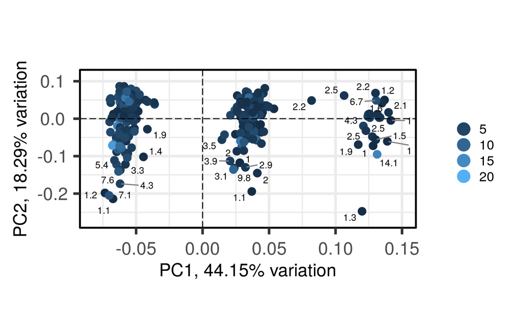

```r
PCA_name <- colnames(p$rotated[1:32])
colnames(pcs$vectors) <- PCA_name
p$rotated <- pcs$vectors
p$components <- PCA_name
p$yvars <- pcs$sample.id
p$xvars <- row.names(pcs$vectors)
p$metadata <- annot_1
p$variance <- setNames(as.numeric(pcs$values), PCA_name)
p$loadings <- c(0, 0)
#biplot(p)

biplot( p, lab = p$metadata$M.Seqs, #change the metata to plot
  hline = 0,
  vline = 0,
  legendPosition = 'right'
)
```

Figure: Metadata number of read

## Pairs plot

```r
pdf(file="PCA ~ pairsplot.pdf", width=20,height=10 )
pairsplot(p)
dev.off()
```

## Corelation plot

```r
pdf(file="PCA ~ Pearson ~ r^2 ~ metadata ~ correlates.pdf", width=20,height=10 )
eigencorplot(
  p,
  components = getComponents(p, 1:10),
  metavars = c(
    'Cultivating.status',
#    'HiSeq.Lane',
#    'Library.pool',
    'Population.name',
    'District',
    'Province',
#    'Sample.type',
#    'Conc..ng.µL.',
#    'A260.A280',
#    "X..Dups",
    "M.Seqs"
#    "gDNA.quality"
  ),
  col = c('white', 'cornsilk1', 'gold', 'forestgreen', 'darkgreen'),
  cexCorval = 1.2,
  fontCorval = 2,
  posLab = 'all',
  rotLabX = 45,
  scale = TRUE,
  main = bquote(Principal ~ component ~ Pearson ~ r ^ 2 ~ metadata ~ correlates),
  plotRsquared = TRUE,
  corFUN = 'pearson',
  corUSE = 'pairwise.complete.obs',
  corMultipleTestCorrection = 'BH',
  signifSymbols = c('****', '***', '**', '*', ''),
  signifCutpoints = c(0, 0.0001, 0.001, 0.01, 0.05, 1)
)
dev.off()
```

## Cultivating status

```r
# Formating the df
pc.df <- as.data.frame(pcs$vectors)
names(pc.df) <- paste0("PC", 1:ncol(pcs$vectors))
pc.df$sample.id <- row.names(pcs$vectors)
pc.df <- left_join(pc.df, pData(annot), by="sample.id")

# Formating the axes names
specify_decimal <- function(x, k) trimws(format(round(x, k), nsmall=k))
Axis_PC1<-paste0("PC1 (",specify_decimal(pcs$values[1],2),"%)")
Axis_PC2<-paste0("PC2 (",specify_decimal(pcs$values[2],2),"%)")
```

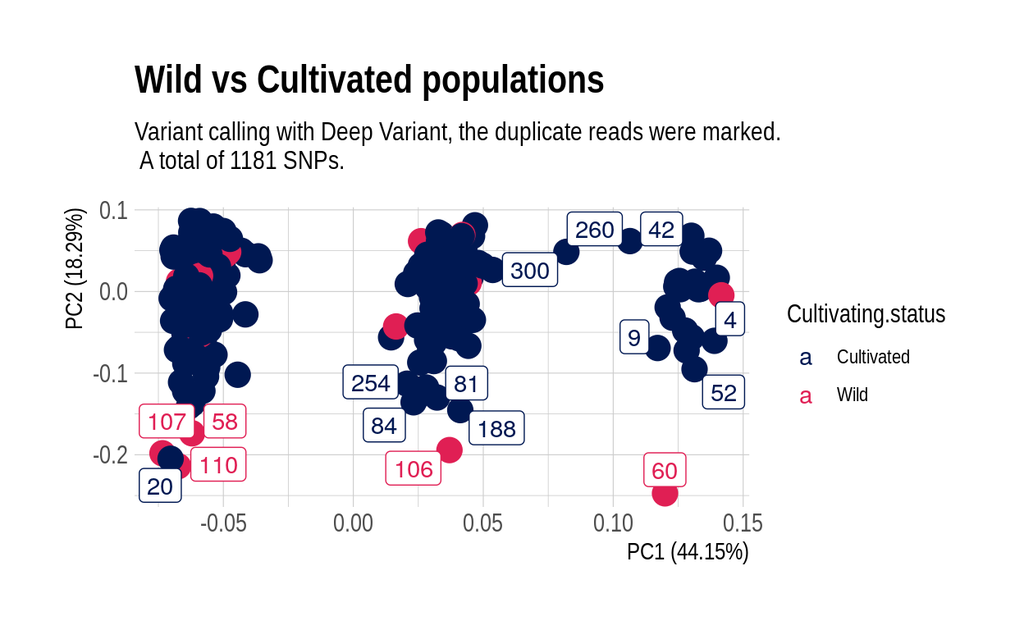

```r
# PCA With domestic vs wild populations

ggplot(pc.df, aes(PC1, PC2, color = Cultivating.status)) +
  geom_point(size = 5) +
  geom_label_repel(
    aes(label = sample.id),
    box.padding   = 0.15,
    point.padding = 0.5,
    segment.color = "grey50",
        max.time = 1,
    max.iter = 2000,
    max.overlaps  = 12
  ) +
  xlab(Axis_PC1) +
  ylab(Axis_PC2) +
  ggtitle("Wild vs Cultivated populations", subtitle = "Variant calling with Deep Variant, the duplicate reads were marked.\n A total of 1181 SNPs.") +
  theme_ipsum(axis_title_size = 11) +
  scale_color_manual(values = c("#001852", "#E01F54"))
```

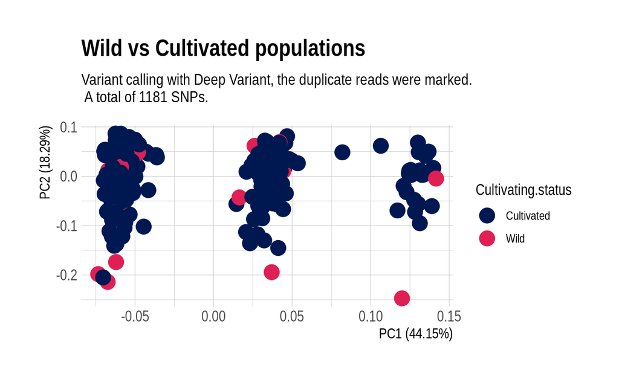

```r
ggsave(
  filename = "Wild vs Cultivated populations - labels.png",
  device = "png",
  width = 20,
  height = 10
)

# PCA With domestic vs wild populations - NO LABELS
ggplot(pc.df, aes(PC1, PC2, color = Cultivating.status)) +
  geom_point(size = 5) +
  xlab(Axis_PC1) +
  ylab(Axis_PC2) +
  ggtitle("Wild vs Cultivated populations", subtitle = "Variant calling with Deep Variant, the duplicate reads were marked.\n A total of 1181 SNPs.") +
  theme_ipsum(axis_title_size = 11) +
  scale_color_manual(values = c("#001852", "#E01F54"))
```

```r
ggsave(
  filename = "Wild vs Cultivated populations - nolabels.png",
  device = "png",
  width = 20,
  height = 10
)
```

## Population name

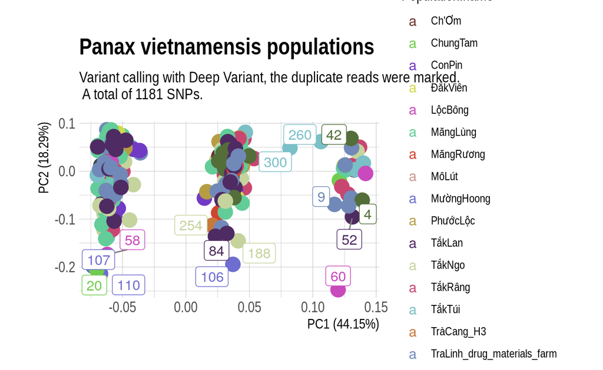

```r
# Formating the color for the PCA
#find the palette at https://medialab.github.io/iwanthue/
pop.cols <- setNames(c("#6c332e", "#71cc4d", "#703ac4", "#d2d94a", "#c94abd", "#62cd98", "#d04430", "#6e6dd0", "#b69d43", "#4f2b63", "#c5d39d", "#c94670",
                       "#7bbfc7", "#c7783b", "#7089b8", "#536e39", "#c98bc2", "#384241", "#c99992"),
                     c("Ch'Ơm","ChungTam","ConPin", "ĐắkViên", "LộcBông", "MăngLùng", "MăngRương", "MườngHoong", "PhướcLộc","TắkLan", "TắkNgo", "TắkRâng",
                       "TắkTúi", "TràCang_H3", "TraLinh_drug_materials_farm", "TràLinh_H3", "TràNam", "Xốp", "MôLút"))

# PCA with the population data
  ggplot(pc.df, aes(PC1, PC2, color = Population.name)) +
  geom_point(size = 5) +
  geom_label_repel(
    aes(label = sample.id),
    box.padding   = 0.15,
    point.padding = 0.2,
    segment.color = 'grey50',
    max.time = 1,
    max.iter = 2000,
    max.overlaps  = 12
  ) +
  xlab(Axis_PC1) + ylab(Axis_PC2) +
  ggtitle("Panax vietnamensis populations", subtitle = "Variant calling with Deep Variant, the duplicate reads were marked.\n A total of 1181 SNPs.") +
  theme_ipsum(axis_title_size = 11) +
  scale_color_manual(values = pop.cols)
```

```r
  ggsave(
  filename = "Panax vietnamensis populations - labels.png",
  device = "png",
  width = 20,
  height = 10
)

# PCA with the population data - NO LABELS
PCA_pop_names_nolabels <-
  ggplot(pc.df, aes(PC1, PC2, color = Population.name)) +
  geom_point(size = 5) +
  xlab(Axis_PC1) + ylab(Axis_PC2) +
  ggtitle("Panax vietnamensis populations", subtitle = "Variant calling with Deep Variant, the duplicate reads were marked.\n A total of 1181 SNPs.") +
  theme_ipsum(axis_title_size = 11) +
  scale_color_manual(values = pop.cols)
ggsave(
  filename = "Panax vietnamensis populations - nolabels.png",
  device = "png",
  width = 20,
  height = 10
)
```

## Hiseq Lane

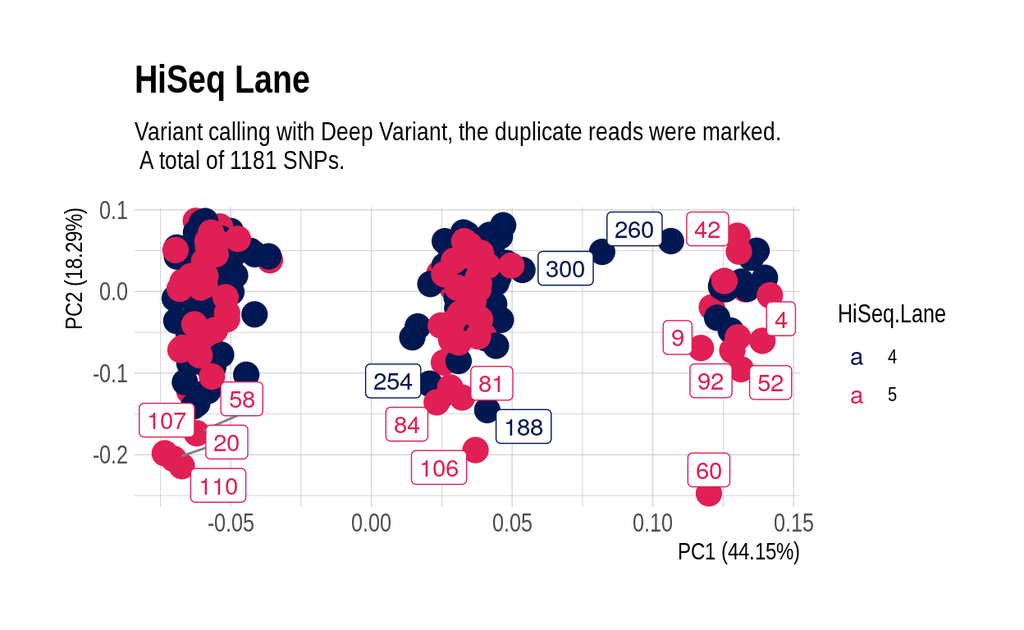

```r
# PCA With domestic vs wild populations
ggplot(pc.df, aes(PC1, PC2, color = HiSeq.Lane)) +
  geom_point(size = 5) +
  geom_label_repel(
    aes(label = sample.id),
    box.padding   = 0.15,
    point.padding = 0.5,
    segment.color = "grey50",
        max.time = 1,
    max.iter = 2000,
    max.overlaps  = 12
  ) +
  xlab(Axis_PC1) +
  ylab(Axis_PC2) +
  ggtitle("HiSeq Lane", subtitle = "Variant calling with Deep Variant, the duplicate reads were marked.\n A total of 1181 SNPs.") +
  theme_ipsum(axis_title_size = 11) +
  scale_color_manual(values = c("#001852", "#E01F54"))
```

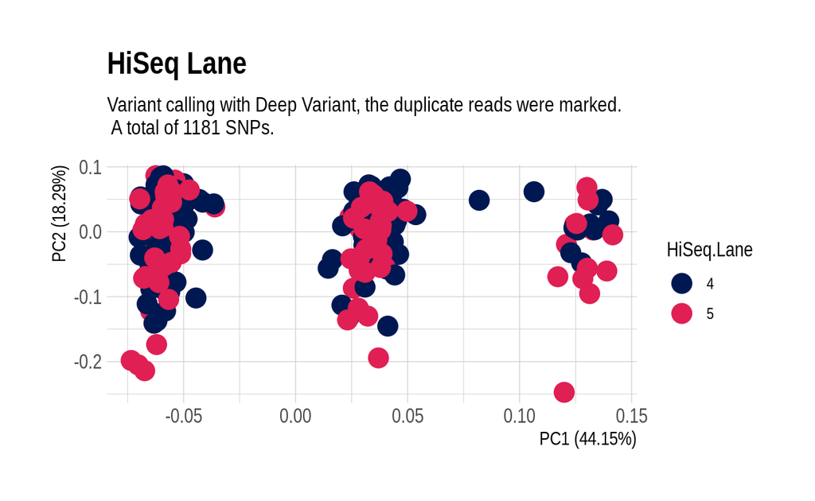

```r
ggsave(
  filename = "HiSeq Lane - labels.png",
  device = "png",
  width = 20,
  height = 10
)

# PCA With domestic vs wild populations - NO LABELS
ggplot(pc.df, aes(PC1, PC2, color = HiSeq.Lane)) +
  geom_point(size = 5) +
  xlab(Axis_PC1) +
  ylab(Axis_PC2) +
  ggtitle("HiSeq Lane", subtitle = "Variant calling with Deep Variant, the duplicate reads were marked.\n A total of 1181 SNPs.") +
  theme_ipsum(axis_title_size = 11) +
  scale_color_manual(values = c("#001852", "#E01F54"))
```

```r
ggsave(
  filename = "HiSeq Lane - nolabels.png",
  device = "png",
  width = 20,
  height = 10
)
```

## Library pool

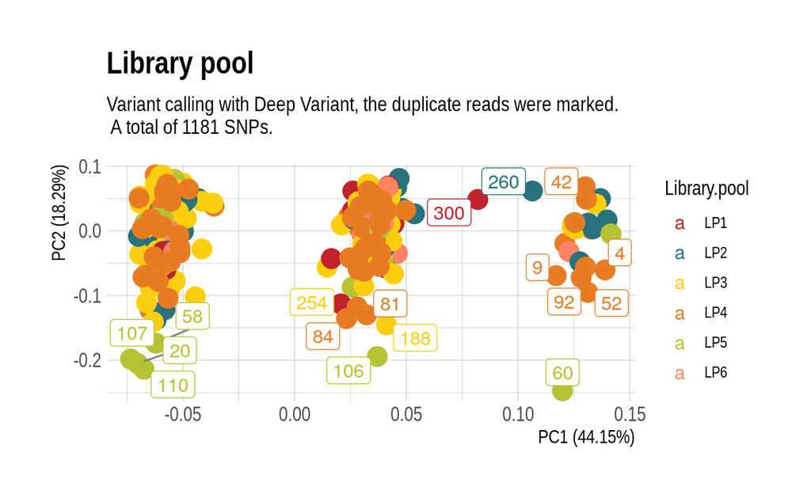

```r
# PCA With domestic vs wild populations
ggplot(pc.df, aes(x = PC1, y = PC2, color = Library.pool)) +
  geom_point(size = 5) +
  geom_label_repel(
    aes(label = sample.id),
    box.padding   = 0.15,
    point.padding = 0.5,
    segment.color = "grey50",
        max.time = 1,
    max.iter = 2000,
    max.overlaps  = 12
  ) +
  xlab(Axis_PC1) +
  ylab(Axis_PC2) +
  ggtitle("Library pool", subtitle = "Variant calling with Deep Variant, the duplicate reads were marked.\n A total of 1181 SNPs.") +
  theme_ipsum(axis_title_size = 11) +
  scale_color_manual(values = c("#c1232b","#27727b", "#fcce10", "#e87c25", "#b5c334", "#fe8463"))
```

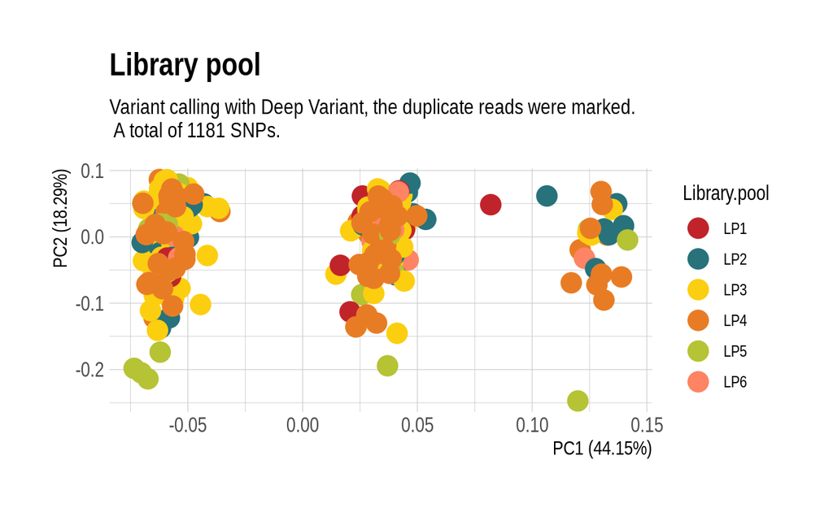

```r
ggsave(
  filename = "Library pool - labels.png",
  device = "png",
  width = 20,
  height = 10
)

# PCA With domestic vs wild populations - NO LABELS
ggplot(pc.df, aes(PC1, PC2, color = Library.pool)) +
  geom_point(size = 5) +
  xlab(Axis_PC1) +
  ylab(Axis_PC2) +
  ggtitle("Library pool", subtitle = "Variant calling with Deep Variant, the duplicate reads were marked.\n A total of 1181 SNPs.") +
  theme_ipsum(axis_title_size = 11) +
  scale_color_manual(values = c("#c1232b","#27727b", "#fcce10", "#e87c25", "#b5c334", "#fe8463"))
```

```r
ggsave(
  filename = "Library pool - nolabels.png",
  device = "png",
  width = 20,
  height = 10
)
```

## Province

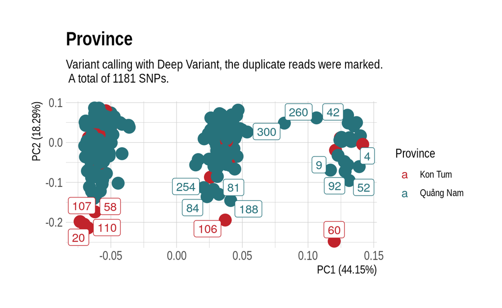

```r
# PCA With domestic vs wild populations
ggplot(pc.df, aes(x = PC1, y = PC2, color = Province)) +
  geom_point(size = 5) +
  geom_label_repel(
    aes(label = sample.id),
    box.padding   = 0.15,
    point.padding = 0.5,
    segment.color = "grey50",
        max.time = 1,
    max.iter = 2000,
    max.overlaps  = 12
  ) +
  xlab(Axis_PC1) +
  ylab(Axis_PC2) +
  ggtitle("Province", subtitle = "Variant calling with Deep Variant, the duplicate reads were marked.\n A total of 1181 SNPs.") +
  theme_ipsum(axis_title_size = 11) +
  scale_color_manual(values = c("#c1232b","#27727b", "#fcce10", "#e87c25", "#b5c334", "#fe8463"))
```

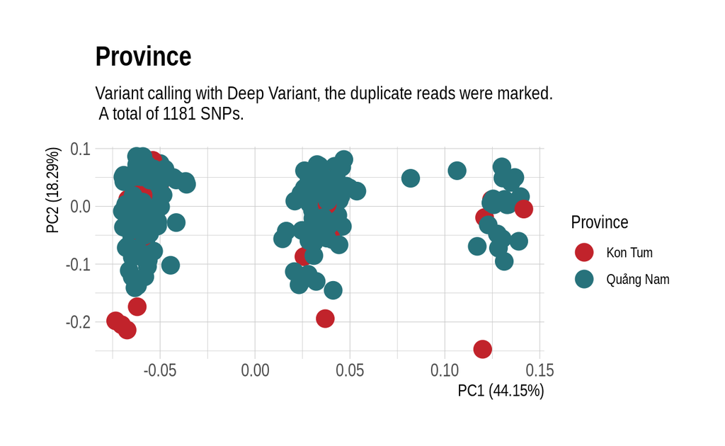

```r
ggsave(
  filename = "Province - labels.png",
  device = "png",
  width = 20,
  height = 10
)

# PCA With domestic vs wild populations - NO LABELS
ggplot(pc.df, aes(PC1, PC2, color = Province)) +
  geom_point(size = 5) +
  xlab(Axis_PC1) +
  ylab(Axis_PC2) +
  ggtitle("Province", subtitle = "Variant calling with Deep Variant, the duplicate reads were marked.\n A total of 1181 SNPs.") +
  theme_ipsum(axis_title_size = 11) +
  scale_color_manual(values = c("#c1232b","#27727b", "#fcce10", "#e87c25", "#b5c334", "#fe8463"))
```

```r
ggsave(
  filename = "Province - nolabels.png",
  device = "png",
  width = 20,
  height = 10
)
```

Reference of the pipeline: https://bioconductor.org/packages/release/bioc/vignettes/PCAtools/inst/doc/PCAtools.html https://popgen.nescent.org/2015-12-15-microsatellite-differentiation.html